# 2024Q1报告

使用em的业绩报告数据。

## 金额

### 总体情况

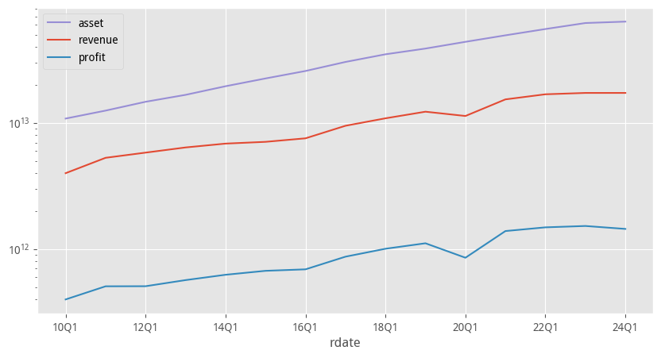

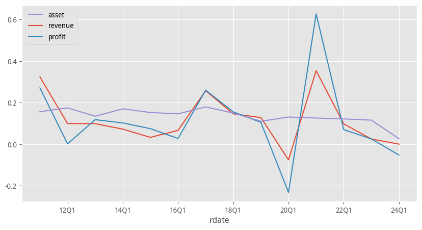

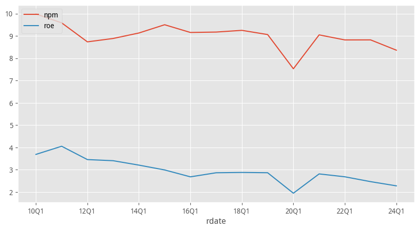

- 总收入还在小幅度增长，但总利润已经开始下降。考虑到前三年上市高峰期，利润的减少实际更严重。
- 利润增长率本季同比为负数。历史上仅疫情第一季出现这种情况。
- 全市场净利率连续第3年同比下滑，但没有下降在2020年的低点。

### 亏损情况

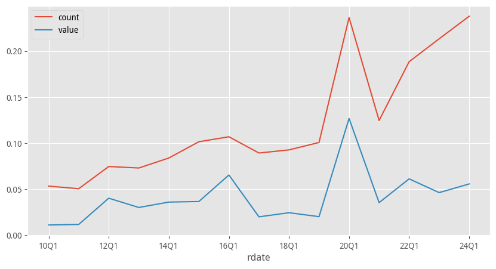

- 亏损家数和金额都在2020年达到历史高点。但2021年又快速回落。
- 亏损家数的比例远大于亏损金额的比例，说明小企业亏损的比例更高。
- 就亏损金额占比而言，2023年Q1显示出下降，但全年令人失望。
- 2024年Q1亏损金额占比又开始回升了。不好的预期。

## 排名

### 最近一年各项指标前20

|  | revenue | profit | asset | cash |
| --- | --- | --- | --- | --- |
| 0 | [中国石油](https://data.eastmoney.com/stockdata/601857.html) | [工商银行](https://data.eastmoney.com/stockdata/601398.html) | [工商银行](https://data.eastmoney.com/stockdata/601398.html) | [工商银行](https://data.eastmoney.com/stockdata/601398.html) |
| 1 | [中国石化](https://data.eastmoney.com/stockdata/600028.html) | [建设银行](https://data.eastmoney.com/stockdata/601939.html) | [建设银行](https://data.eastmoney.com/stockdata/601939.html) | [农业银行](https://data.eastmoney.com/stockdata/601288.html) |
| 2 | [中国建筑](https://data.eastmoney.com/stockdata/601668.html) | [农业银行](https://data.eastmoney.com/stockdata/601288.html) | [农业银行](https://data.eastmoney.com/stockdata/601288.html) | [邮储银行](https://data.eastmoney.com/stockdata/601658.html) |
| 3 | [中国铁建](https://data.eastmoney.com/stockdata/601186.html) | [中国银行](https://data.eastmoney.com/stockdata/601988.html) | [中国银行](https://data.eastmoney.com/stockdata/601988.html) | [建设银行](https://data.eastmoney.com/stockdata/601939.html) |
| 4 | [中国中铁](https://data.eastmoney.com/stockdata/601390.html) | [中国石油](https://data.eastmoney.com/stockdata/601857.html) | [中国石油](https://data.eastmoney.com/stockdata/601857.html) | [中国人寿](https://data.eastmoney.com/stockdata/601628.html) |
| 5 | [中国移动](https://data.eastmoney.com/stockdata/600941.html) | [中国海油](https://data.eastmoney.com/stockdata/600938.html) | [中国移动](https://data.eastmoney.com/stockdata/600941.html) | [中国石油](https://data.eastmoney.com/stockdata/601857.html) |
| 6 | [中国平安](https://data.eastmoney.com/stockdata/601318.html) | [招商银行](https://data.eastmoney.com/stockdata/600036.html) | [招商银行](https://data.eastmoney.com/stockdata/600036.html) | [中国银河](https://data.eastmoney.com/stockdata/601881.html) |
| 7 | [工商银行](https://data.eastmoney.com/stockdata/601398.html) | [中国平安](https://data.eastmoney.com/stockdata/601318.html) | [交通银行](https://data.eastmoney.com/stockdata/601328.html) | [宁波银行](https://data.eastmoney.com/stockdata/002142.html) |
| 8 | [建设银行](https://data.eastmoney.com/stockdata/601939.html) | [中国移动](https://data.eastmoney.com/stockdata/600941.html) | [中国平安](https://data.eastmoney.com/stockdata/601318.html) | [江苏银行](https://data.eastmoney.com/stockdata/600919.html) |
| 9 | [农业银行](https://data.eastmoney.com/stockdata/601288.html) | [邮储银行](https://data.eastmoney.com/stockdata/601658.html) | [邮储银行](https://data.eastmoney.com/stockdata/601658.html) | [中信证券](https://data.eastmoney.com/stockdata/600030.html) |
| 10 | [中国交建](https://data.eastmoney.com/stockdata/601800.html) | [交通银行](https://data.eastmoney.com/stockdata/601328.html) | [中国石化](https://data.eastmoney.com/stockdata/600028.html) | [中国平安](https://data.eastmoney.com/stockdata/601318.html) |
| 11 | [中国银行](https://data.eastmoney.com/stockdata/601988.html) | [兴业银行](https://data.eastmoney.com/stockdata/601166.html) | [兴业银行](https://data.eastmoney.com/stockdata/601166.html) | [渝农商行](https://data.eastmoney.com/stockdata/601077.html) |
| 12 | [中国中冶](https://data.eastmoney.com/stockdata/601618.html) | [贵州茅台](https://data.eastmoney.com/stockdata/600519.html) | [中国海油](https://data.eastmoney.com/stockdata/600938.html) | [中国海油](https://data.eastmoney.com/stockdata/600938.html) |
| 13 | [上汽集团](https://data.eastmoney.com/stockdata/600104.html) | [中国人寿](https://data.eastmoney.com/stockdata/601628.html) | [浦发银行](https://data.eastmoney.com/stockdata/600000.html) | [中国移动](https://data.eastmoney.com/stockdata/600941.html) |
| 14 | [中国电建](https://data.eastmoney.com/stockdata/601669.html) | [中信银行](https://data.eastmoney.com/stockdata/601998.html) | [中信银行](https://data.eastmoney.com/stockdata/601998.html) | [中国太保](https://data.eastmoney.com/stockdata/601601.html) |
| 15 | [中国人保](https://data.eastmoney.com/stockdata/601319.html) | [中国石化](https://data.eastmoney.com/stockdata/600028.html) | [民生银行](https://data.eastmoney.com/stockdata/600016.html) | [新华保险](https://data.eastmoney.com/stockdata/601336.html) |
| 16 | [中国电信](https://data.eastmoney.com/stockdata/601728.html) | [浦发银行](https://data.eastmoney.com/stockdata/600000.html) | [光大银行](https://data.eastmoney.com/stockdata/601818.html) | [中国人保](https://data.eastmoney.com/stockdata/601319.html) |
| 17 | [物产中大](https://data.eastmoney.com/stockdata/600704.html) | [中国神华](https://data.eastmoney.com/stockdata/601088.html) | [中国人寿](https://data.eastmoney.com/stockdata/601628.html) | [华泰证券](https://data.eastmoney.com/stockdata/601688.html) |
| 18 | [建发股份](https://data.eastmoney.com/stockdata/600153.html) | [平安银行](https://data.eastmoney.com/stockdata/000001.html) | [平安银行](https://data.eastmoney.com/stockdata/000001.html) | [沪农商行](https://data.eastmoney.com/stockdata/601825.html) |
| 19 | [比亚迪](https://data.eastmoney.com/stockdata/002594.html) | [中国建筑](https://data.eastmoney.com/stockdata/601668.html) | [中国电信](https://data.eastmoney.com/stockdata/601728.html) | [中国神华](https://data.eastmoney.com/stockdata/601088.html) |

- 收入巨头出现了一个新贵，比BYD。

### 历年进入过前300

```
revenue top 300: 556
profit top 300: 813
asset top 300: 622
cash top 300: 1119
total: 64 | top 20 : 65.59%
```

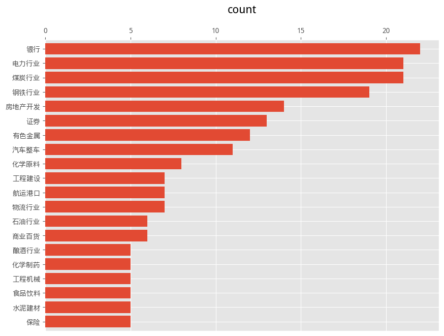

```
top 300 in all cols: 311
total: 311 | from 15 to 1
```

|  | 1 | 2 | 3 | 4 | 5 | 6 | 7 | 8 | 9 | 10 |
| --- | --- | --- | --- | --- | --- | --- | --- | --- | --- | --- |
| 0 | [山东黄金](https://data.eastmoney.com/stockdata/600547.html) | [中远海控](https://data.eastmoney.com/stockdata/601919.html) | [金发科技](https://data.eastmoney.com/stockdata/600143.html) | [柳钢股份](https://data.eastmoney.com/stockdata/601003.html) | [格力电器](https://data.eastmoney.com/stockdata/000651.html) | [东方电气](https://data.eastmoney.com/stockdata/600875.html) | [比亚迪](https://data.eastmoney.com/stockdata/002594.html) | [本钢板材](https://data.eastmoney.com/stockdata/000761.html) | [太钢不锈](https://data.eastmoney.com/stockdata/000825.html) | [中国联通](https://data.eastmoney.com/stockdata/600050.html) |
| 1 | [中国铝业](https://data.eastmoney.com/stockdata/601600.html) | [TCL科技](https://data.eastmoney.com/stockdata/000100.html) | [上海医药](https://data.eastmoney.com/stockdata/601607.html) | [一汽解放](https://data.eastmoney.com/stockdata/000800.html) | [光大银行](https://data.eastmoney.com/stockdata/601818.html) | [云南铜业](https://data.eastmoney.com/stockdata/000878.html) | [海信视像](https://data.eastmoney.com/stockdata/600060.html) | [中国银行](https://data.eastmoney.com/stockdata/601988.html) | [四川长虹](https://data.eastmoney.com/stockdata/600839.html) | [国电电力](https://data.eastmoney.com/stockdata/600795.html) |
| 2 | [河钢股份](https://data.eastmoney.com/stockdata/000709.html) | [爱施德](https://data.eastmoney.com/stockdata/002416.html) | [平安银行](https://data.eastmoney.com/stockdata/000001.html) | [中国中铁](https://data.eastmoney.com/stockdata/601390.html) | [中国石化](https://data.eastmoney.com/stockdata/600028.html) | [中国中免](https://data.eastmoney.com/stockdata/601888.html) | [万华化学](https://data.eastmoney.com/stockdata/600309.html) | [中国铁建](https://data.eastmoney.com/stockdata/601186.html) | [中国东航](https://data.eastmoney.com/stockdata/600115.html) | [华电国际](https://data.eastmoney.com/stockdata/600027.html) |
| 3 | [江淮汽车](https://data.eastmoney.com/stockdata/600418.html) | [中集集团](https://data.eastmoney.com/stockdata/000039.html) | [中国电建](https://data.eastmoney.com/stockdata/601669.html) | [上海石化](https://data.eastmoney.com/stockdata/600688.html) | [山东钢铁](https://data.eastmoney.com/stockdata/600022.html) | [伊利股份](https://data.eastmoney.com/stockdata/600887.html) | [招商银行](https://data.eastmoney.com/stockdata/600036.html) | [南钢股份](https://data.eastmoney.com/stockdata/600282.html) | [三一重工](https://data.eastmoney.com/stockdata/600031.html) | [美的集团](https://data.eastmoney.com/stockdata/000333.html) |
| 4 | [中国石油](https://data.eastmoney.com/stockdata/601857.html) | [紫金矿业](https://data.eastmoney.com/stockdata/601899.html) | [福田汽车](https://data.eastmoney.com/stockdata/600166.html) | [国投电力](https://data.eastmoney.com/stockdata/600886.html) | [洋河股份](https://data.eastmoney.com/stockdata/002304.html) | [江西铜业](https://data.eastmoney.com/stockdata/600362.html) | [酒钢宏兴](https://data.eastmoney.com/stockdata/600307.html) | [广州发展](https://data.eastmoney.com/stockdata/600098.html) | [华锦股份](https://data.eastmoney.com/stockdata/000059.html) | [海尔智家](https://data.eastmoney.com/stockdata/600690.html) |
| 5 | [长安汽车](https://data.eastmoney.com/stockdata/000625.html) | [金隅集团](https://data.eastmoney.com/stockdata/601992.html) | [ST易购](https://data.eastmoney.com/stockdata/002024.html) | [中煤能源](https://data.eastmoney.com/stockdata/601898.html) | [中国神华](https://data.eastmoney.com/stockdata/601088.html) | [中国化学](https://data.eastmoney.com/stockdata/601117.html) | [海螺水泥](https://data.eastmoney.com/stockdata/600585.html) | [云南白药](https://data.eastmoney.com/stockdata/000538.html) | [长江电力](https://data.eastmoney.com/stockdata/600900.html) | [首钢股份](https://data.eastmoney.com/stockdata/000959.html) |
| 6 | [潍柴动力](https://data.eastmoney.com/stockdata/000338.html) | [中信银行](https://data.eastmoney.com/stockdata/601998.html) | [工商银行](https://data.eastmoney.com/stockdata/601398.html) | [中联重科](https://data.eastmoney.com/stockdata/000157.html) | [青岛啤酒](https://data.eastmoney.com/stockdata/600600.html) | [建发股份](https://data.eastmoney.com/stockdata/600153.html) | [大秦铁路](https://data.eastmoney.com/stockdata/601006.html) | [山西焦煤](https://data.eastmoney.com/stockdata/000983.html) | [南方航空](https://data.eastmoney.com/stockdata/600029.html) | [特变电工](https://data.eastmoney.com/stockdata/600089.html) |
| 7 | [双汇发展](https://data.eastmoney.com/stockdata/000895.html) | [铜陵有色](https://data.eastmoney.com/stockdata/000630.html) | [西部矿业](https://data.eastmoney.com/stockdata/601168.html) | [华夏银行](https://data.eastmoney.com/stockdata/600015.html) | [锡业股份](https://data.eastmoney.com/stockdata/000960.html) | [中兴通讯](https://data.eastmoney.com/stockdata/000063.html) | [中国人寿](https://data.eastmoney.com/stockdata/601628.html) | [华域汽车](https://data.eastmoney.com/stockdata/600741.html) | [兖矿能源](https://data.eastmoney.com/stockdata/600188.html) | [徐工机械](https://data.eastmoney.com/stockdata/000425.html) |
| 8 | [包钢股份](https://data.eastmoney.com/stockdata/600010.html) | [隧道股份](https://data.eastmoney.com/stockdata/600820.html) | [厦门国贸](https://data.eastmoney.com/stockdata/600755.html) | [中国太保](https://data.eastmoney.com/stockdata/601601.html) | [豫园股份](https://data.eastmoney.com/stockdata/600655.html) | [华能国际](https://data.eastmoney.com/stockdata/600011.html) | [大唐发电](https://data.eastmoney.com/stockdata/601991.html) | [宝钢股份](https://data.eastmoney.com/stockdata/600019.html) | [中国重汽](https://data.eastmoney.com/stockdata/000951.html) | [广汽集团](https://data.eastmoney.com/stockdata/601238.html) |
| 9 | [中信证券](https://data.eastmoney.com/stockdata/600030.html) | [民生银行](https://data.eastmoney.com/stockdata/600016.html) | [浦发银行](https://data.eastmoney.com/stockdata/600000.html) | [马钢股份](https://data.eastmoney.com/stockdata/600808.html) | [建设银行](https://data.eastmoney.com/stockdata/601939.html) | [鞍钢股份](https://data.eastmoney.com/stockdata/000898.html) | [上海电力](https://data.eastmoney.com/stockdata/600021.html) | [中金黄金](https://data.eastmoney.com/stockdata/600489.html) | [贵州茅台](https://data.eastmoney.com/stockdata/600519.html) | [农业银行](https://data.eastmoney.com/stockdata/601288.html) |
| 10 | [兴业银行](https://data.eastmoney.com/stockdata/601166.html) | [华菱钢铁](https://data.eastmoney.com/stockdata/000932.html) | [中国核电](https://data.eastmoney.com/stockdata/601985.html) | [上汽集团](https://data.eastmoney.com/stockdata/600104.html) | [温氏股份](https://data.eastmoney.com/stockdata/300498.html) | [新兴铸管](https://data.eastmoney.com/stockdata/000778.html) | [荣盛石化](https://data.eastmoney.com/stockdata/002493.html) | [百联股份](https://data.eastmoney.com/stockdata/600827.html) | [云天化](https://data.eastmoney.com/stockdata/600096.html) | [交通银行](https://data.eastmoney.com/stockdata/601328.html) |
| 11 | [中国国航](https://data.eastmoney.com/stockdata/601111.html) | [保利发展](https://data.eastmoney.com/stockdata/600048.html) | [中储股份](https://data.eastmoney.com/stockdata/600787.html) | [中国中车](https://data.eastmoney.com/stockdata/601766.html) | [五矿发展](https://data.eastmoney.com/stockdata/600058.html) | [中国平安](https://data.eastmoney.com/stockdata/601318.html) | [华谊集团](https://data.eastmoney.com/stockdata/600623.html) | [杭钢股份](https://data.eastmoney.com/stockdata/600126.html) | [潞安环能](https://data.eastmoney.com/stockdata/601699.html) | [桐昆股份](https://data.eastmoney.com/stockdata/601233.html) |
| 12 | [宁波银行](https://data.eastmoney.com/stockdata/002142.html) | [长城汽车](https://data.eastmoney.com/stockdata/601633.html) | [上港集团](https://data.eastmoney.com/stockdata/600018.html) | [厦门象屿](https://data.eastmoney.com/stockdata/600057.html) | [太阳纸业](https://data.eastmoney.com/stockdata/002078.html) | [三钢闽光](https://data.eastmoney.com/stockdata/002110.html) | [华阳股份](https://data.eastmoney.com/stockdata/600348.html) | [中国船舶](https://data.eastmoney.com/stockdata/600150.html) | [云铝股份](https://data.eastmoney.com/stockdata/000807.html) | [恒逸石化](https://data.eastmoney.com/stockdata/000703.html) |
| 13 | [新华保险](https://data.eastmoney.com/stockdata/601336.html) | [中材国际](https://data.eastmoney.com/stockdata/600970.html) | [海通证券](https://data.eastmoney.com/stockdata/600837.html) | [南京银行](https://data.eastmoney.com/stockdata/601009.html) | [中南股份](https://data.eastmoney.com/stockdata/000717.html) | [中金岭南](https://data.eastmoney.com/stockdata/000060.html) | [晨鸣纸业](https://data.eastmoney.com/stockdata/000488.html) | [神火股份](https://data.eastmoney.com/stockdata/000933.html) | [四川路桥](https://data.eastmoney.com/stockdata/600039.html) | [平煤股份](https://data.eastmoney.com/stockdata/601666.html) |
| 14 | [申能股份](https://data.eastmoney.com/stockdata/600642.html) | [中国重工](https://data.eastmoney.com/stockdata/601989.html) | [浙能电力](https://data.eastmoney.com/stockdata/600023.html) | [陕西煤业](https://data.eastmoney.com/stockdata/601225.html) | [冀中能源](https://data.eastmoney.com/stockdata/000937.html) | [江铃汽车](https://data.eastmoney.com/stockdata/000550.html) | [白云山](https://data.eastmoney.com/stockdata/600332.html) | [中国广核](https://data.eastmoney.com/stockdata/003816.html) | [国泰君安](https://data.eastmoney.com/stockdata/601211.html) | [福耀玻璃](https://data.eastmoney.com/stockdata/600660.html) |
| 15 | [复星医药](https://data.eastmoney.com/stockdata/600196.html) | [正泰电器](https://data.eastmoney.com/stockdata/601877.html) | [中海油服](https://data.eastmoney.com/stockdata/601808.html) | [鲁西化工](https://data.eastmoney.com/stockdata/000830.html) | [王府井](https://data.eastmoney.com/stockdata/600859.html) | [南山铝业](https://data.eastmoney.com/stockdata/600219.html) | [荣盛发展](https://data.eastmoney.com/stockdata/002146.html) | [广深铁路](https://data.eastmoney.com/stockdata/601333.html) | [大商股份](https://data.eastmoney.com/stockdata/600694.html) | [三友化工](https://data.eastmoney.com/stockdata/600409.html) |
| 16 | [龙源电力](https://data.eastmoney.com/stockdata/001289.html) | [ST中泰](https://data.eastmoney.com/stockdata/002092.html) | [*ST金科](https://data.eastmoney.com/stockdata/000656.html) | [中天科技](https://data.eastmoney.com/stockdata/600522.html) | [绿地控股](https://data.eastmoney.com/stockdata/600606.html) | [紫光股份](https://data.eastmoney.com/stockdata/000938.html) | [恒力石化](https://data.eastmoney.com/stockdata/600346.html) | [宇通客车](https://data.eastmoney.com/stockdata/600066.html) | [中油资本](https://data.eastmoney.com/stockdata/000617.html) | [招商蛇口](https://data.eastmoney.com/stockdata/001979.html) |
| 17 | [海天味业](https://data.eastmoney.com/stockdata/603288.html) | [开滦股份](https://data.eastmoney.com/stockdata/600997.html) | [通威股份](https://data.eastmoney.com/stockdata/600438.html) | [华泰证券](https://data.eastmoney.com/stockdata/601688.html) | [上海银行](https://data.eastmoney.com/stockdata/601229.html) | [际华集团](https://data.eastmoney.com/stockdata/601718.html) | [蓝思科技](https://data.eastmoney.com/stockdata/300433.html) | [江苏银行](https://data.eastmoney.com/stockdata/600919.html) | [顺丰控股](https://data.eastmoney.com/stockdata/002352.html) | [中信特钢](https://data.eastmoney.com/stockdata/000708.html) |
| 18 | [郑煤机](https://data.eastmoney.com/stockdata/601717.html) | [中远海发](https://data.eastmoney.com/stockdata/601866.html) | [广发证券](https://data.eastmoney.com/stockdata/000776.html) | [华新水泥](https://data.eastmoney.com/stockdata/600801.html) | [立讯精密](https://data.eastmoney.com/stockdata/002475.html) | [京能电力](https://data.eastmoney.com/stockdata/600578.html) | [上海机电](https://data.eastmoney.com/stockdata/600835.html) | [中铁工业](https://data.eastmoney.com/stockdata/600528.html) | [宁波港](https://data.eastmoney.com/stockdata/601018.html) | [深圳能源](https://data.eastmoney.com/stockdata/000027.html) |
| 19 | [浙江龙盛](https://data.eastmoney.com/stockdata/600352.html) | [首开股份](https://data.eastmoney.com/stockdata/600376.html) | [雅戈尔](https://data.eastmoney.com/stockdata/600177.html) | [工业富联](https://data.eastmoney.com/stockdata/601138.html) | [圆通速递](https://data.eastmoney.com/stockdata/600233.html) | [浙商银行](https://data.eastmoney.com/stockdata/601916.html) | [邮储银行](https://data.eastmoney.com/stockdata/601658.html) | [中国人保](https://data.eastmoney.com/stockdata/601319.html) | [哈药股份](https://data.eastmoney.com/stockdata/600664.html) | [海油发展](https://data.eastmoney.com/stockdata/600968.html) |
| 20 | [歌尔股份](https://data.eastmoney.com/stockdata/002241.html) | [金正大](https://data.eastmoney.com/stockdata/002470.html) | [杭州银行](https://data.eastmoney.com/stockdata/600926.html) | [湖北宜化](https://data.eastmoney.com/stockdata/000422.html) | [淮北矿业](https://data.eastmoney.com/stockdata/600985.html) | [洛阳钼业](https://data.eastmoney.com/stockdata/603993.html) | [闻泰科技](https://data.eastmoney.com/stockdata/600745.html) | [山西汾酒](https://data.eastmoney.com/stockdata/600809.html) | [中远海能](https://data.eastmoney.com/stockdata/600026.html) | [渝农商行](https://data.eastmoney.com/stockdata/601077.html) |
| 21 | [渤海租赁](https://data.eastmoney.com/stockdata/000415.html) | [隆基绿能](https://data.eastmoney.com/stockdata/601012.html) | [宁德时代](https://data.eastmoney.com/stockdata/300750.html) | [海澜之家](https://data.eastmoney.com/stockdata/600398.html) | [北方稀土](https://data.eastmoney.com/stockdata/600111.html) | [郑州煤电](https://data.eastmoney.com/stockdata/600121.html) | [中国西电](https://data.eastmoney.com/stockdata/601179.html) | [中船防务](https://data.eastmoney.com/stockdata/600685.html) | [华发股份](https://data.eastmoney.com/stockdata/600325.html) | [中孚实业](https://data.eastmoney.com/stockdata/600595.html) |
| 22 | [长电科技](https://data.eastmoney.com/stockdata/600584.html) | [新城控股](https://data.eastmoney.com/stockdata/601155.html) | [中国动力](https://data.eastmoney.com/stockdata/600482.html) | [申万宏源](https://data.eastmoney.com/stockdata/000166.html) | [钒钛股份](https://data.eastmoney.com/stockdata/000629.html) | [驰宏锌锗](https://data.eastmoney.com/stockdata/600497.html) | [天津港](https://data.eastmoney.com/stockdata/600717.html) | [滨江集团](https://data.eastmoney.com/stockdata/002244.html) | [大悦城](https://data.eastmoney.com/stockdata/000031.html) | [新奥股份](https://data.eastmoney.com/stockdata/600803.html) |
| 23 | [泸州老窖](https://data.eastmoney.com/stockdata/000568.html) | [牧原股份](https://data.eastmoney.com/stockdata/002714.html) | [中芯国际](https://data.eastmoney.com/stockdata/688981.html) | [天合光能](https://data.eastmoney.com/stockdata/688599.html) | [亚泰集团](https://data.eastmoney.com/stockdata/600881.html) | [山推股份](https://data.eastmoney.com/stockdata/000680.html) | [内蒙华电](https://data.eastmoney.com/stockdata/600863.html) | [中国移动](https://data.eastmoney.com/stockdata/600941.html) | [晶澳科技](https://data.eastmoney.com/stockdata/002459.html) | [安源煤业](https://data.eastmoney.com/stockdata/600397.html) |
| 24 | [中国海油](https://data.eastmoney.com/stockdata/600938.html) | [中文传媒](https://data.eastmoney.com/stockdata/600373.html) | [京沪高铁](https://data.eastmoney.com/stockdata/601816.html) | [山鹰国际](https://data.eastmoney.com/stockdata/600567.html) | [中国通号](https://data.eastmoney.com/stockdata/688009.html) | [北大荒](https://data.eastmoney.com/stockdata/600598.html) | [天山股份](https://data.eastmoney.com/stockdata/000877.html) | [晋控煤业](https://data.eastmoney.com/stockdata/601001.html) | [美邦服饰](https://data.eastmoney.com/stockdata/002269.html) | [TCL中环](https://data.eastmoney.com/stockdata/002129.html) |
| 25 | [永泰能源](https://data.eastmoney.com/stockdata/600157.html) | [上海能源](https://data.eastmoney.com/stockdata/600508.html) | [中国银河](https://data.eastmoney.com/stockdata/601881.html) | [卫星化学](https://data.eastmoney.com/stockdata/002648.html) | [皖能电力](https://data.eastmoney.com/stockdata/000543.html) | [东方明珠](https://data.eastmoney.com/stockdata/600637.html) | [迈瑞医疗](https://data.eastmoney.com/stockdata/300760.html) | [电投能源](https://data.eastmoney.com/stockdata/002128.html) | [恒源煤电](https://data.eastmoney.com/stockdata/600971.html) | [药明康德](https://data.eastmoney.com/stockdata/603259.html) |
| 26 | [大有能源](https://data.eastmoney.com/stockdata/600403.html) | [金钼股份](https://data.eastmoney.com/stockdata/601958.html) | [海南橡胶](https://data.eastmoney.com/stockdata/601118.html) | [天山铝业](https://data.eastmoney.com/stockdata/002532.html) | [海油工程](https://data.eastmoney.com/stockdata/600583.html) | [华友钴业](https://data.eastmoney.com/stockdata/603799.html) | [紫江企业](https://data.eastmoney.com/stockdata/600210.html) | [新集能源](https://data.eastmoney.com/stockdata/601918.html) | [恒瑞医药](https://data.eastmoney.com/stockdata/600276.html) | [巨化股份](https://data.eastmoney.com/stockdata/600160.html) |
| 27 | [广汇能源](https://data.eastmoney.com/stockdata/600256.html) | [万向钱潮](https://data.eastmoney.com/stockdata/000559.html) | [中粮糖业](https://data.eastmoney.com/stockdata/600737.html) | [国信证券](https://data.eastmoney.com/stockdata/002736.html) | [盘江股份](https://data.eastmoney.com/stockdata/600395.html) | [宝丰能源](https://data.eastmoney.com/stockdata/600989.html) | [北辰实业](https://data.eastmoney.com/stockdata/601588.html) | [湖北能源](https://data.eastmoney.com/stockdata/000883.html) | [华鲁恒升](https://data.eastmoney.com/stockdata/600426.html) | [人福医药](https://data.eastmoney.com/stockdata/600079.html) |
| 28 | [亿纬锂能](https://data.eastmoney.com/stockdata/300014.html) | [太原重工](https://data.eastmoney.com/stockdata/600169.html) | [华润双鹤](https://data.eastmoney.com/stockdata/600062.html) | [保变电气](https://data.eastmoney.com/stockdata/600550.html) | [信达地产](https://data.eastmoney.com/stockdata/600657.html) | [小商品城](https://data.eastmoney.com/stockdata/600415.html) | [中华企业](https://data.eastmoney.com/stockdata/600675.html) | [大连重工](https://data.eastmoney.com/stockdata/002204.html) | [赣锋锂业](https://data.eastmoney.com/stockdata/002460.html) | [电广传媒](https://data.eastmoney.com/stockdata/000917.html) |
| 29 | [中绿电](https://data.eastmoney.com/stockdata/000537.html) | [万达电影](https://data.eastmoney.com/stockdata/002739.html) | [陆家嘴](https://data.eastmoney.com/stockdata/600663.html) | [建投能源](https://data.eastmoney.com/stockdata/000600.html) | [栖霞建设](https://data.eastmoney.com/stockdata/600533.html) | [宁沪高速](https://data.eastmoney.com/stockdata/600377.html) | [天齐锂业](https://data.eastmoney.com/stockdata/002466.html) | [ST旭电](https://data.eastmoney.com/stockdata/000413.html) | [鹏鼎控股](https://data.eastmoney.com/stockdata/002938.html) | [招商轮船](https://data.eastmoney.com/stockdata/601872.html) |
| 30 | [中金公司](https://data.eastmoney.com/stockdata/601995.html) | [辽宁成大](https://data.eastmoney.com/stockdata/600739.html) | [兰花科创](https://data.eastmoney.com/stockdata/600123.html) | [光大证券](https://data.eastmoney.com/stockdata/601788.html) | [长沙银行](https://data.eastmoney.com/stockdata/601577.html) | [兴业证券](https://data.eastmoney.com/stockdata/601377.html) | [国投资本](https://data.eastmoney.com/stockdata/600061.html) | [福星股份](https://data.eastmoney.com/stockdata/000926.html) | [梅花生物](https://data.eastmoney.com/stockdata/600873.html) | [东方集团](https://data.eastmoney.com/stockdata/600811.html) |
| 31 | [东方证券](https://data.eastmoney.com/stockdata/600958.html) |  |  |  |  |  |  |  |  |  |

- 四个指标都进入过前300强的有311家。
- 收入巨头最稳定，而现金巨头最不稳定。

### 每年都进入前300

```
revenue all time top 300: 173
total: 45 | top 20 : 78.61%
```

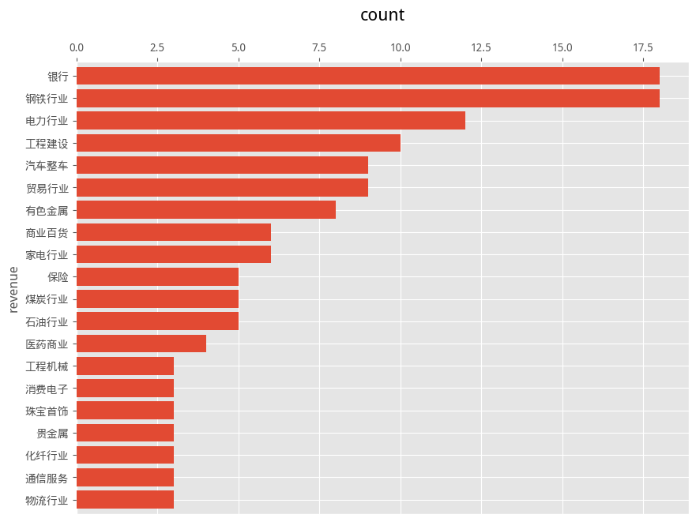

```
total: 173 | from 15 to 3
```

|  | 1 | 2 | 3 | 4 | 5 | 6 | 7 | 8 | 9 | 10 |
| --- | --- | --- | --- | --- | --- | --- | --- | --- | --- | --- |
| 0 | [东方创业](https://data.eastmoney.com/stockdata/600278.html) | [中远海控](https://data.eastmoney.com/stockdata/601919.html) | [中国电建](https://data.eastmoney.com/stockdata/601669.html) | [上海建工](https://data.eastmoney.com/stockdata/600170.html) | [上海石化](https://data.eastmoney.com/stockdata/600688.html) | [太钢不锈](https://data.eastmoney.com/stockdata/000825.html) | [鞍钢股份](https://data.eastmoney.com/stockdata/000898.html) | [美的集团](https://data.eastmoney.com/stockdata/000333.html) | [交通银行](https://data.eastmoney.com/stockdata/601328.html) | [华能国际](https://data.eastmoney.com/stockdata/600011.html) |
| 1 | [五矿发展](https://data.eastmoney.com/stockdata/600058.html) | [河钢股份](https://data.eastmoney.com/stockdata/000709.html) | [中国铝业](https://data.eastmoney.com/stockdata/601600.html) | [中国神华](https://data.eastmoney.com/stockdata/601088.html) | [中国中冶](https://data.eastmoney.com/stockdata/601618.html) | [中国太保](https://data.eastmoney.com/stockdata/601601.html) | [云天化](https://data.eastmoney.com/stockdata/600096.html) | [比亚迪](https://data.eastmoney.com/stockdata/002594.html) | [中兴通讯](https://data.eastmoney.com/stockdata/000063.html) | [海尔智家](https://data.eastmoney.com/stockdata/600690.html) |
| 2 | [福田汽车](https://data.eastmoney.com/stockdata/600166.html) | [上海电气](https://data.eastmoney.com/stockdata/601727.html) | [马钢股份](https://data.eastmoney.com/stockdata/600808.html) | [中国国航](https://data.eastmoney.com/stockdata/601111.html) | [大唐发电](https://data.eastmoney.com/stockdata/601991.html) | [潍柴动力](https://data.eastmoney.com/stockdata/000338.html) | [中国东航](https://data.eastmoney.com/stockdata/600115.html) | [中煤能源](https://data.eastmoney.com/stockdata/601898.html) | [招商银行](https://data.eastmoney.com/stockdata/600036.html) | [江西铜业](https://data.eastmoney.com/stockdata/600362.html) |
| 3 | [ST易购](https://data.eastmoney.com/stockdata/002024.html) | [南方航空](https://data.eastmoney.com/stockdata/600029.html) | [中国中免](https://data.eastmoney.com/stockdata/601888.html) | [兴业银行](https://data.eastmoney.com/stockdata/601166.html) | [大秦铁路](https://data.eastmoney.com/stockdata/601006.html) | [华域汽车](https://data.eastmoney.com/stockdata/600741.html) | [格力电器](https://data.eastmoney.com/stockdata/000651.html) | [本钢板材](https://data.eastmoney.com/stockdata/000761.html) | [华电国际](https://data.eastmoney.com/stockdata/600027.html) | [浦发银行](https://data.eastmoney.com/stockdata/600000.html) |
| 4 | [TCL科技](https://data.eastmoney.com/stockdata/000100.html) | [铜陵有色](https://data.eastmoney.com/stockdata/000630.html) | [中信银行](https://data.eastmoney.com/stockdata/601998.html) | [民生银行](https://data.eastmoney.com/stockdata/600016.html) | [中国中车](https://data.eastmoney.com/stockdata/601766.html) | [华菱钢铁](https://data.eastmoney.com/stockdata/000932.html) | [建发股份](https://data.eastmoney.com/stockdata/600153.html) | [广州发展](https://data.eastmoney.com/stockdata/600098.html) | [洋河股份](https://data.eastmoney.com/stockdata/002304.html) | [海亮股份](https://data.eastmoney.com/stockdata/002203.html) |
| 5 | [浙商中拓](https://data.eastmoney.com/stockdata/000906.html) | [华东医药](https://data.eastmoney.com/stockdata/000963.html) | [中化国际](https://data.eastmoney.com/stockdata/600500.html) | [中集集团](https://data.eastmoney.com/stockdata/000039.html) | [双汇发展](https://data.eastmoney.com/stockdata/000895.html) | [江淮汽车](https://data.eastmoney.com/stockdata/600418.html) | [一汽解放](https://data.eastmoney.com/stockdata/000800.html) | [百联股份](https://data.eastmoney.com/stockdata/600827.html) | [光大银行](https://data.eastmoney.com/stockdata/601818.html) | [酒钢宏兴](https://data.eastmoney.com/stockdata/600307.html) |
| 6 | [四川长虹](https://data.eastmoney.com/stockdata/600839.html) | [包钢股份](https://data.eastmoney.com/stockdata/600010.html) | [国电电力](https://data.eastmoney.com/stockdata/600795.html) | [新兴铸管](https://data.eastmoney.com/stockdata/000778.html) | [长安汽车](https://data.eastmoney.com/stockdata/000625.html) | [上海医药](https://data.eastmoney.com/stockdata/601607.html) | [首钢股份](https://data.eastmoney.com/stockdata/000959.html) | [厦门国贸](https://data.eastmoney.com/stockdata/600755.html) | [南钢股份](https://data.eastmoney.com/stockdata/600282.html) | [东方电气](https://data.eastmoney.com/stockdata/600875.html) |
| 7 | [物产中大](https://data.eastmoney.com/stockdata/600704.html) | [伊利股份](https://data.eastmoney.com/stockdata/600887.html) | [兖矿能源](https://data.eastmoney.com/stockdata/600188.html) | [柳钢股份](https://data.eastmoney.com/stockdata/601003.html) | [三一重工](https://data.eastmoney.com/stockdata/600031.html) | [新钢股份](https://data.eastmoney.com/stockdata/600782.html) | [山东钢铁](https://data.eastmoney.com/stockdata/600022.html) | [金发科技](https://data.eastmoney.com/stockdata/600143.html) | [锡业股份](https://data.eastmoney.com/stockdata/000960.html) | [广汽集团](https://data.eastmoney.com/stockdata/601238.html) |
| 8 | [万华化学](https://data.eastmoney.com/stockdata/600309.html) | [云南白药](https://data.eastmoney.com/stockdata/000538.html) | [华谊集团](https://data.eastmoney.com/stockdata/600623.html) | [云南铜业](https://data.eastmoney.com/stockdata/000878.html) | [天音控股](https://data.eastmoney.com/stockdata/000829.html) | [徐工机械](https://data.eastmoney.com/stockdata/000425.html) | [华夏银行](https://data.eastmoney.com/stockdata/600015.html) | [中联重科](https://data.eastmoney.com/stockdata/000157.html) | [安阳钢铁](https://data.eastmoney.com/stockdata/600569.html) | [山东黄金](https://data.eastmoney.com/stockdata/600547.html) |
| 9 | [中国重汽](https://data.eastmoney.com/stockdata/000951.html) | [海螺水泥](https://data.eastmoney.com/stockdata/600585.html) | [紫金矿业](https://data.eastmoney.com/stockdata/601899.html) | [中国化学](https://data.eastmoney.com/stockdata/601117.html) | [厦门信达](https://data.eastmoney.com/stockdata/000701.html) | [西部矿业](https://data.eastmoney.com/stockdata/601168.html) | [爱施德](https://data.eastmoney.com/stockdata/002416.html) | [永辉超市](https://data.eastmoney.com/stockdata/601933.html) | [豫园股份](https://data.eastmoney.com/stockdata/600655.html) | [长江电力](https://data.eastmoney.com/stockdata/600900.html) |
| 10 | [保利发展](https://data.eastmoney.com/stockdata/600048.html) | [中信证券](https://data.eastmoney.com/stockdata/600030.html) | [平安银行](https://data.eastmoney.com/stockdata/000001.html) | [青岛啤酒](https://data.eastmoney.com/stockdata/600600.html) | [老凤祥](https://data.eastmoney.com/stockdata/600612.html) | [远大控股](https://data.eastmoney.com/stockdata/000626.html) | [温氏股份](https://data.eastmoney.com/stockdata/300498.html) | [杭钢股份](https://data.eastmoney.com/stockdata/600126.html) | [中金黄金](https://data.eastmoney.com/stockdata/600489.html) | [海信视像](https://data.eastmoney.com/stockdata/600060.html) |
| 11 | [九州通](https://data.eastmoney.com/stockdata/600998.html) | [国药一致](https://data.eastmoney.com/stockdata/000028.html) | [贵州茅台](https://data.eastmoney.com/stockdata/600519.html) | [荣盛石化](https://data.eastmoney.com/stockdata/002493.html) | [山西焦煤](https://data.eastmoney.com/stockdata/000983.html) | [中国核电](https://data.eastmoney.com/stockdata/601985.html) | [华锦股份](https://data.eastmoney.com/stockdata/000059.html) | [北京银行](https://data.eastmoney.com/stockdata/601169.html) | [金隅集团](https://data.eastmoney.com/stockdata/601992.html) | [上海电力](https://data.eastmoney.com/stockdata/600021.html) |
| 12 | [隧道股份](https://data.eastmoney.com/stockdata/600820.html) | [石化油服](https://data.eastmoney.com/stockdata/600871.html) | [国投电力](https://data.eastmoney.com/stockdata/600886.html) | [海信家电](https://data.eastmoney.com/stockdata/000921.html) | [南京医药](https://data.eastmoney.com/stockdata/600713.html) | [中储股份](https://data.eastmoney.com/stockdata/600787.html) | [特变电工](https://data.eastmoney.com/stockdata/600089.html) | [中国联通](https://data.eastmoney.com/stockdata/600050.html) | [宝钢股份](https://data.eastmoney.com/stockdata/600019.html) | [中国交建](https://data.eastmoney.com/stockdata/601800.html) |
| 13 | [中国平安](https://data.eastmoney.com/stockdata/601318.html) | [中国电信](https://data.eastmoney.com/stockdata/601728.html) | [中国建筑](https://data.eastmoney.com/stockdata/601668.html) | [上汽集团](https://data.eastmoney.com/stockdata/600104.html) | [农业银行](https://data.eastmoney.com/stockdata/601288.html) | [中国银行](https://data.eastmoney.com/stockdata/601988.html) | [中国铁建](https://data.eastmoney.com/stockdata/601186.html) | [建设银行](https://data.eastmoney.com/stockdata/601939.html) | [中国中铁](https://data.eastmoney.com/stockdata/601390.html) | [工商银行](https://data.eastmoney.com/stockdata/601398.html) |
| 14 | [中国人寿](https://data.eastmoney.com/stockdata/601628.html) | [中国石油](https://data.eastmoney.com/stockdata/601857.html) | [中国石化](https://data.eastmoney.com/stockdata/600028.html) | [新华保险](https://data.eastmoney.com/stockdata/601336.html) | [长城汽车](https://data.eastmoney.com/stockdata/601633.html) | [环旭电子](https://data.eastmoney.com/stockdata/601231.html) | [桐昆股份](https://data.eastmoney.com/stockdata/601233.html) | [新凤鸣](https://data.eastmoney.com/stockdata/603225.html) | [陕西煤业](https://data.eastmoney.com/stockdata/601225.html) | [浙能电力](https://data.eastmoney.com/stockdata/600023.html) |
| 15 | [中国广核](https://data.eastmoney.com/stockdata/003816.html) | [国泰君安](https://data.eastmoney.com/stockdata/601211.html) | [龙源电力](https://data.eastmoney.com/stockdata/001289.html) | [中国核建](https://data.eastmoney.com/stockdata/601611.html) | [白银有色](https://data.eastmoney.com/stockdata/601212.html) | [江苏银行](https://data.eastmoney.com/stockdata/600919.html) | [上海银行](https://data.eastmoney.com/stockdata/601229.html) | [金田股份](https://data.eastmoney.com/stockdata/601609.html) | [邮储银行](https://data.eastmoney.com/stockdata/601658.html) | [工业富联](https://data.eastmoney.com/stockdata/601138.html) |
| 16 | [浙商银行](https://data.eastmoney.com/stockdata/601916.html) | [中国人保](https://data.eastmoney.com/stockdata/601319.html) | [海油发展](https://data.eastmoney.com/stockdata/600968.html) | [传音控股](https://data.eastmoney.com/stockdata/688036.html) | [金龙鱼](https://data.eastmoney.com/stockdata/300999.html) | [天合光能](https://data.eastmoney.com/stockdata/688599.html) | [中国黄金](https://data.eastmoney.com/stockdata/600916.html) | [友发集团](https://data.eastmoney.com/stockdata/601686.html) | [物产环能](https://data.eastmoney.com/stockdata/603071.html) | [中国移动](https://data.eastmoney.com/stockdata/600941.html) |
| 17 | [中国海油](https://data.eastmoney.com/stockdata/600938.html) | [中信金属](https://data.eastmoney.com/stockdata/601061.html) | [中电港](https://data.eastmoney.com/stockdata/001287.html) |  |  |  |  |  |  |  |

```
profit all time top 300: 101
total: 31 | top 20 : 89.11%
```

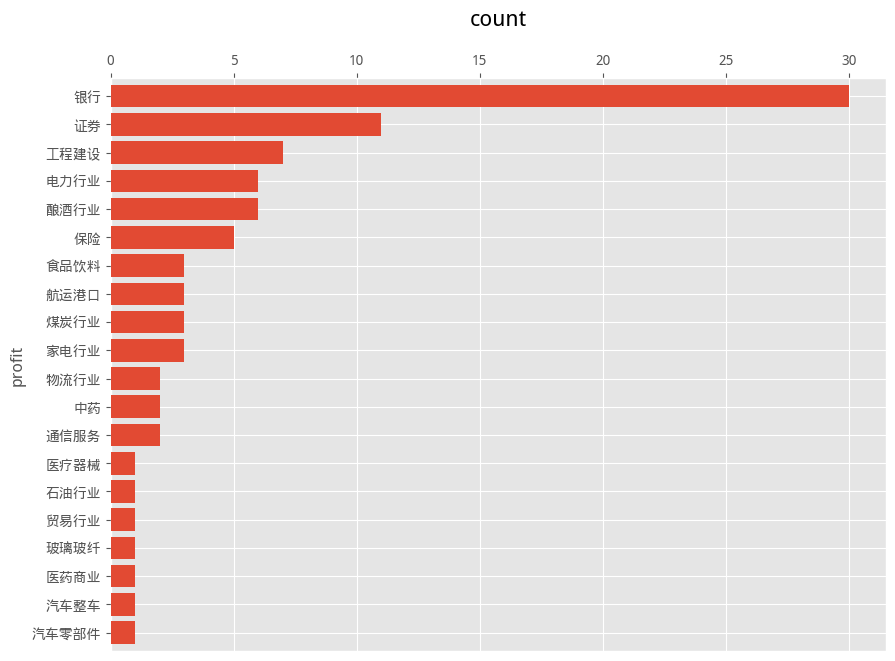

```
total: 101 | from 15 to 3
```

|  | 1 | 2 | 3 | 4 | 5 | 6 | 7 | 8 | 9 | 10 |
| --- | --- | --- | --- | --- | --- | --- | --- | --- | --- | --- |
| 0 | [工商银行](https://data.eastmoney.com/stockdata/601398.html) | [建设银行](https://data.eastmoney.com/stockdata/601939.html) | [中国中冶](https://data.eastmoney.com/stockdata/601618.html) | [上港集团](https://data.eastmoney.com/stockdata/600018.html) | [贵州茅台](https://data.eastmoney.com/stockdata/600519.html) | [海通证券](https://data.eastmoney.com/stockdata/600837.html) | [华夏银行](https://data.eastmoney.com/stockdata/600015.html) | [广发证券](https://data.eastmoney.com/stockdata/000776.html) | [宝钢股份](https://data.eastmoney.com/stockdata/600019.html) | [光大银行](https://data.eastmoney.com/stockdata/601818.html) |
| 1 | [华泰证券](https://data.eastmoney.com/stockdata/601688.html) | [海螺水泥](https://data.eastmoney.com/stockdata/600585.html) | [招商证券](https://data.eastmoney.com/stockdata/600999.html) | [洋河股份](https://data.eastmoney.com/stockdata/002304.html) | [上汽集团](https://data.eastmoney.com/stockdata/600104.html) | [光大证券](https://data.eastmoney.com/stockdata/601788.html) | [中国化学](https://data.eastmoney.com/stockdata/601117.html) | [长江电力](https://data.eastmoney.com/stockdata/600900.html) | [宁波港](https://data.eastmoney.com/stockdata/601018.html) | [上海医药](https://data.eastmoney.com/stockdata/601607.html) |
| 2 | [海尔智家](https://data.eastmoney.com/stockdata/600690.html) | [宁波银行](https://data.eastmoney.com/stockdata/002142.html) | [福耀玻璃](https://data.eastmoney.com/stockdata/600660.html) | [中国核电](https://data.eastmoney.com/stockdata/601985.html) | [建发股份](https://data.eastmoney.com/stockdata/600153.html) | [电投能源](https://data.eastmoney.com/stockdata/002128.html) | [保利发展](https://data.eastmoney.com/stockdata/600048.html) | [南京银行](https://data.eastmoney.com/stockdata/601009.html) | [中国电建](https://data.eastmoney.com/stockdata/601669.html) | [格力电器](https://data.eastmoney.com/stockdata/000651.html) |
| 3 | [泸州老窖](https://data.eastmoney.com/stockdata/000568.html) | [特变电工](https://data.eastmoney.com/stockdata/600089.html) | [中国建筑](https://data.eastmoney.com/stockdata/601668.html) | [中国铁建](https://data.eastmoney.com/stockdata/601186.html) | [平安银行](https://data.eastmoney.com/stockdata/000001.html) | [潍柴动力](https://data.eastmoney.com/stockdata/000338.html) | [中国交建](https://data.eastmoney.com/stockdata/601800.html) | [中国银行](https://data.eastmoney.com/stockdata/601988.html) | [中国神华](https://data.eastmoney.com/stockdata/601088.html) | [中国电信](https://data.eastmoney.com/stockdata/601728.html) |
| 4 | [招商银行](https://data.eastmoney.com/stockdata/600036.html) | [中国平安](https://data.eastmoney.com/stockdata/601318.html) | [兖矿能源](https://data.eastmoney.com/stockdata/600188.html) | [北京银行](https://data.eastmoney.com/stockdata/601169.html) | [中国太保](https://data.eastmoney.com/stockdata/601601.html) | [大秦铁路](https://data.eastmoney.com/stockdata/601006.html) | [兴业银行](https://data.eastmoney.com/stockdata/601166.html) | [浦发银行](https://data.eastmoney.com/stockdata/600000.html) | [民生银行](https://data.eastmoney.com/stockdata/600016.html) | [中信银行](https://data.eastmoney.com/stockdata/601998.html) |
| 5 | [中信证券](https://data.eastmoney.com/stockdata/600030.html) | [中国人寿](https://data.eastmoney.com/stockdata/601628.html) | [中国中铁](https://data.eastmoney.com/stockdata/601390.html) | [伊利股份](https://data.eastmoney.com/stockdata/600887.html) | [美的集团](https://data.eastmoney.com/stockdata/000333.html) | [青岛啤酒](https://data.eastmoney.com/stockdata/600600.html) | [交通银行](https://data.eastmoney.com/stockdata/601328.html) | [农业银行](https://data.eastmoney.com/stockdata/601288.html) | [云南白药](https://data.eastmoney.com/stockdata/000538.html) | [雅戈尔](https://data.eastmoney.com/stockdata/600177.html) |
| 6 | [海康威视](https://data.eastmoney.com/stockdata/002415.html) | [恒瑞医药](https://data.eastmoney.com/stockdata/600276.html) | [山西汾酒](https://data.eastmoney.com/stockdata/600809.html) | [万华化学](https://data.eastmoney.com/stockdata/600309.html) | [双汇发展](https://data.eastmoney.com/stockdata/000895.html) | [华润三九](https://data.eastmoney.com/stockdata/000999.html) | [新华保险](https://data.eastmoney.com/stockdata/601336.html) | [浙能电力](https://data.eastmoney.com/stockdata/600023.html) | [海天味业](https://data.eastmoney.com/stockdata/603288.html) | [今世缘](https://data.eastmoney.com/stockdata/603369.html) |
| 7 | [国信证券](https://data.eastmoney.com/stockdata/002736.html) | [申万宏源](https://data.eastmoney.com/stockdata/000166.html) | [国泰君安](https://data.eastmoney.com/stockdata/601211.html) | [中国广核](https://data.eastmoney.com/stockdata/003816.html) | [贵阳银行](https://data.eastmoney.com/stockdata/601997.html) | [龙源电力](https://data.eastmoney.com/stockdata/001289.html) | [杭州银行](https://data.eastmoney.com/stockdata/600926.html) | [郑州银行](https://data.eastmoney.com/stockdata/002936.html) | [中国银河](https://data.eastmoney.com/stockdata/601881.html) | [江苏银行](https://data.eastmoney.com/stockdata/600919.html) |
| 8 | [上海银行](https://data.eastmoney.com/stockdata/601229.html) | [浙商银行](https://data.eastmoney.com/stockdata/601916.html) | [渝农商行](https://data.eastmoney.com/stockdata/601077.html) | [长沙银行](https://data.eastmoney.com/stockdata/601577.html) | [成都银行](https://data.eastmoney.com/stockdata/601838.html) | [邮储银行](https://data.eastmoney.com/stockdata/601658.html) | [青农商行](https://data.eastmoney.com/stockdata/002958.html) | [新天绿能](https://data.eastmoney.com/stockdata/600956.html) | [工业富联](https://data.eastmoney.com/stockdata/601138.html) | [西安银行](https://data.eastmoney.com/stockdata/600928.html) |
| 9 | [中国通号](https://data.eastmoney.com/stockdata/688009.html) | [苏州银行](https://data.eastmoney.com/stockdata/002966.html) | [青岛港](https://data.eastmoney.com/stockdata/601298.html) | [中国人保](https://data.eastmoney.com/stockdata/601319.html) | [中金公司](https://data.eastmoney.com/stockdata/601995.html) | [迈瑞医疗](https://data.eastmoney.com/stockdata/300760.html) | [青岛银行](https://data.eastmoney.com/stockdata/002948.html) | [中国海油](https://data.eastmoney.com/stockdata/600938.html) | [中国移动](https://data.eastmoney.com/stockdata/600941.html) | [东航物流](https://data.eastmoney.com/stockdata/601156.html) |
| 10 | [陕西能源](https://data.eastmoney.com/stockdata/001286.html) |  |  |  |  |  |  |  |  |  |

```
asset all time top 300: 187
total: 47 | top 20 : 79.68%
```

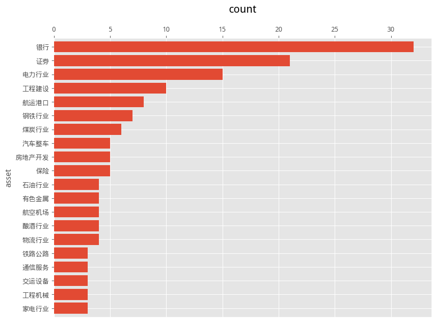

```
total: 187 | from 15 to 3
```

|  | 1 | 2 | 3 | 4 | 5 | 6 | 7 | 8 | 9 | 10 |
| --- | --- | --- | --- | --- | --- | --- | --- | --- | --- | --- |
| 0 | [大秦铁路](https://data.eastmoney.com/stockdata/601006.html) | [光大银行](https://data.eastmoney.com/stockdata/601818.html) | [中国建筑](https://data.eastmoney.com/stockdata/601668.html) | [长江电力](https://data.eastmoney.com/stockdata/600900.html) | [中国铝业](https://data.eastmoney.com/stockdata/601600.html) | [鞍钢股份](https://data.eastmoney.com/stockdata/000898.html) | [中国中铁](https://data.eastmoney.com/stockdata/601390.html) | [中国铁建](https://data.eastmoney.com/stockdata/601186.html) | [兴业银行](https://data.eastmoney.com/stockdata/601166.html) | [中信证券](https://data.eastmoney.com/stockdata/600030.html) |
| 1 | [中国太保](https://data.eastmoney.com/stockdata/601601.html) | [中国联通](https://data.eastmoney.com/stockdata/600050.html) | [中国重工](https://data.eastmoney.com/stockdata/601989.html) | [中煤能源](https://data.eastmoney.com/stockdata/601898.html) | [中国平安](https://data.eastmoney.com/stockdata/601318.html) | [中远海发](https://data.eastmoney.com/stockdata/601866.html) | [中国国航](https://data.eastmoney.com/stockdata/601111.html) | [广深铁路](https://data.eastmoney.com/stockdata/601333.html) | [光大证券](https://data.eastmoney.com/stockdata/601788.html) | [太钢不锈](https://data.eastmoney.com/stockdata/000825.html) |
| 2 | [宁沪高速](https://data.eastmoney.com/stockdata/600377.html) | [保利发展](https://data.eastmoney.com/stockdata/600048.html) | [河钢股份](https://data.eastmoney.com/stockdata/000709.html) | [马钢股份](https://data.eastmoney.com/stockdata/600808.html) | [华夏银行](https://data.eastmoney.com/stockdata/600015.html) | [海螺水泥](https://data.eastmoney.com/stockdata/600585.html) | [华能国际](https://data.eastmoney.com/stockdata/600011.html) | [中远海控](https://data.eastmoney.com/stockdata/601919.html) | [上港集团](https://data.eastmoney.com/stockdata/600018.html) | [中国中冶](https://data.eastmoney.com/stockdata/601618.html) |
| 3 | [上汽集团](https://data.eastmoney.com/stockdata/600104.html) | [海通证券](https://data.eastmoney.com/stockdata/600837.html) | [广发证券](https://data.eastmoney.com/stockdata/000776.html) | [华电国际](https://data.eastmoney.com/stockdata/600027.html) | [上海电气](https://data.eastmoney.com/stockdata/601727.html) | [中海油服](https://data.eastmoney.com/stockdata/601808.html) | [平安银行](https://data.eastmoney.com/stockdata/000001.html) | [紫金矿业](https://data.eastmoney.com/stockdata/601899.html) | [中兴通讯](https://data.eastmoney.com/stockdata/000063.html) | [中国中车](https://data.eastmoney.com/stockdata/601766.html) |
| 4 | [华泰证券](https://data.eastmoney.com/stockdata/601688.html) | [国电电力](https://data.eastmoney.com/stockdata/600795.html) | [江西铜业](https://data.eastmoney.com/stockdata/600362.html) | [中远海能](https://data.eastmoney.com/stockdata/600026.html) | [申能股份](https://data.eastmoney.com/stockdata/600642.html) | [中集集团](https://data.eastmoney.com/stockdata/000039.html) | [中国船舶](https://data.eastmoney.com/stockdata/600150.html) | [深圳能源](https://data.eastmoney.com/stockdata/000027.html) | [华域汽车](https://data.eastmoney.com/stockdata/600741.html) | [中联重科](https://data.eastmoney.com/stockdata/000157.html) |
| 5 | [新兴铸管](https://data.eastmoney.com/stockdata/000778.html) | [南山铝业](https://data.eastmoney.com/stockdata/600219.html) | [包钢股份](https://data.eastmoney.com/stockdata/600010.html) | [潍柴动力](https://data.eastmoney.com/stockdata/000338.html) | [青岛啤酒](https://data.eastmoney.com/stockdata/600600.html) | [湖北能源](https://data.eastmoney.com/stockdata/000883.html) | [贵州茅台](https://data.eastmoney.com/stockdata/600519.html) | [雅戈尔](https://data.eastmoney.com/stockdata/600177.html) | [金地集团](https://data.eastmoney.com/stockdata/600383.html) | [格力电器](https://data.eastmoney.com/stockdata/000651.html) |
| 6 | [国元证券](https://data.eastmoney.com/stockdata/000728.html) | [南京银行](https://data.eastmoney.com/stockdata/601009.html) | [中国化学](https://data.eastmoney.com/stockdata/601117.html) | [山西焦煤](https://data.eastmoney.com/stockdata/000983.html) | [南方航空](https://data.eastmoney.com/stockdata/600029.html) | [三一重工](https://data.eastmoney.com/stockdata/600031.html) | [上海机场](https://data.eastmoney.com/stockdata/600009.html) | [东方电气](https://data.eastmoney.com/stockdata/600875.html) | [长江证券](https://data.eastmoney.com/stockdata/000783.html) | [山东高速](https://data.eastmoney.com/stockdata/600350.html) |
| 7 | [招商轮船](https://data.eastmoney.com/stockdata/601872.html) | [长安汽车](https://data.eastmoney.com/stockdata/000625.html) | [宁波银行](https://data.eastmoney.com/stockdata/002142.html) | [兖矿能源](https://data.eastmoney.com/stockdata/600188.html) | [潞安环能](https://data.eastmoney.com/stockdata/601699.html) | [海油工程](https://data.eastmoney.com/stockdata/600583.html) | [上海建工](https://data.eastmoney.com/stockdata/600170.html) | [云南白药](https://data.eastmoney.com/stockdata/000538.html) | [伊利股份](https://data.eastmoney.com/stockdata/600887.html) | [民生银行](https://data.eastmoney.com/stockdata/600016.html) |
| 8 | [中国石油](https://data.eastmoney.com/stockdata/601857.html) | [工商银行](https://data.eastmoney.com/stockdata/601398.html) | [豫园股份](https://data.eastmoney.com/stockdata/600655.html) | [浙江龙盛](https://data.eastmoney.com/stockdata/600352.html) | [隧道股份](https://data.eastmoney.com/stockdata/600820.html) | [招商银行](https://data.eastmoney.com/stockdata/600036.html) | [交通银行](https://data.eastmoney.com/stockdata/601328.html) | [中国神华](https://data.eastmoney.com/stockdata/601088.html) | [中国东航](https://data.eastmoney.com/stockdata/600115.html) | [中国人寿](https://data.eastmoney.com/stockdata/601628.html) |
| 9 | [中国银行](https://data.eastmoney.com/stockdata/601988.html) | [建设银行](https://data.eastmoney.com/stockdata/601939.html) | [农业银行](https://data.eastmoney.com/stockdata/601288.html) | [中国石化](https://data.eastmoney.com/stockdata/600028.html) | [中国中免](https://data.eastmoney.com/stockdata/601888.html) | [山东黄金](https://data.eastmoney.com/stockdata/600547.html) | [福耀玻璃](https://data.eastmoney.com/stockdata/600660.html) | [建发股份](https://data.eastmoney.com/stockdata/600153.html) | [川投能源](https://data.eastmoney.com/stockdata/600674.html) | [万华化学](https://data.eastmoney.com/stockdata/600309.html) |
| 10 | [TCL科技](https://data.eastmoney.com/stockdata/000100.html) | [金风科技](https://data.eastmoney.com/stockdata/002202.html) | [洋河股份](https://data.eastmoney.com/stockdata/002304.html) | [泸州老窖](https://data.eastmoney.com/stockdata/000568.html) | [徐工机械](https://data.eastmoney.com/stockdata/000425.html) | [吉林敖东](https://data.eastmoney.com/stockdata/000623.html) | [铜陵有色](https://data.eastmoney.com/stockdata/000630.html) | [海尔智家](https://data.eastmoney.com/stockdata/600690.html) | [特变电工](https://data.eastmoney.com/stockdata/600089.html) | [辽宁成大](https://data.eastmoney.com/stockdata/600739.html) |
| 11 | [复星医药](https://data.eastmoney.com/stockdata/600196.html) | [新湖中宝](https://data.eastmoney.com/stockdata/600208.html) | [广州发展](https://data.eastmoney.com/stockdata/600098.html) | [上海医药](https://data.eastmoney.com/stockdata/601607.html) | [宝钢股份](https://data.eastmoney.com/stockdata/600019.html) | [中信银行](https://data.eastmoney.com/stockdata/601998.html) | [宁波港](https://data.eastmoney.com/stockdata/601018.html) | [新华保险](https://data.eastmoney.com/stockdata/601336.html) | [金隅集团](https://data.eastmoney.com/stockdata/601992.html) | [西南证券](https://data.eastmoney.com/stockdata/600369.html) |
| 12 | [辽港股份](https://data.eastmoney.com/stockdata/601880.html) | [长城汽车](https://data.eastmoney.com/stockdata/601633.html) | [兴业证券](https://data.eastmoney.com/stockdata/601377.html) | [比亚迪](https://data.eastmoney.com/stockdata/002594.html) | [上海石化](https://data.eastmoney.com/stockdata/600688.html) | [中国电建](https://data.eastmoney.com/stockdata/601669.html) | [方正证券](https://data.eastmoney.com/stockdata/601901.html) | [广汽集团](https://data.eastmoney.com/stockdata/601238.html) | [中国交建](https://data.eastmoney.com/stockdata/601800.html) | [浦发银行](https://data.eastmoney.com/stockdata/600000.html) |
| 13 | [东吴证券](https://data.eastmoney.com/stockdata/601555.html) | [陕西煤业](https://data.eastmoney.com/stockdata/601225.html) | [浙能电力](https://data.eastmoney.com/stockdata/600023.html) | [洛阳钼业](https://data.eastmoney.com/stockdata/603993.html) | [美的集团](https://data.eastmoney.com/stockdata/000333.html) | [东方证券](https://data.eastmoney.com/stockdata/600958.html) | [国信证券](https://data.eastmoney.com/stockdata/002736.html) | [东兴证券](https://data.eastmoney.com/stockdata/601198.html) | [蓝思科技](https://data.eastmoney.com/stockdata/300433.html) | [国泰君安](https://data.eastmoney.com/stockdata/601211.html) |
| 14 | [申万宏源](https://data.eastmoney.com/stockdata/000166.html) | [新城控股](https://data.eastmoney.com/stockdata/601155.html) | [中国核电](https://data.eastmoney.com/stockdata/601985.html) | [温氏股份](https://data.eastmoney.com/stockdata/300498.html) | [招商蛇口](https://data.eastmoney.com/stockdata/001979.html) | [贵阳银行](https://data.eastmoney.com/stockdata/601997.html) | [江苏银行](https://data.eastmoney.com/stockdata/600919.html) | [齐鲁银行](https://data.eastmoney.com/stockdata/601665.html) | [中国银河](https://data.eastmoney.com/stockdata/601881.html) | [上海银行](https://data.eastmoney.com/stockdata/601229.html) |
| 15 | [杭州银行](https://data.eastmoney.com/stockdata/600926.html) | [财通证券](https://data.eastmoney.com/stockdata/601108.html) | [招商公路](https://data.eastmoney.com/stockdata/001965.html) | [美凯龙](https://data.eastmoney.com/stockdata/601828.html) | [华能水电](https://data.eastmoney.com/stockdata/600025.html) | [成都银行](https://data.eastmoney.com/stockdata/601838.html) | [宁德时代](https://data.eastmoney.com/stockdata/300750.html) | [中国人保](https://data.eastmoney.com/stockdata/601319.html) | [工业富联](https://data.eastmoney.com/stockdata/601138.html) | [中信建投](https://data.eastmoney.com/stockdata/601066.html) |
| 16 | [中国广核](https://data.eastmoney.com/stockdata/003816.html) | [青农商行](https://data.eastmoney.com/stockdata/002958.html) | [青岛银行](https://data.eastmoney.com/stockdata/002948.html) | [西安银行](https://data.eastmoney.com/stockdata/600928.html) | [中国外运](https://data.eastmoney.com/stockdata/601598.html) | [青岛港](https://data.eastmoney.com/stockdata/601298.html) | [长沙银行](https://data.eastmoney.com/stockdata/601577.html) | [郑州银行](https://data.eastmoney.com/stockdata/002936.html) | [苏州银行](https://data.eastmoney.com/stockdata/002966.html) | [中国通号](https://data.eastmoney.com/stockdata/688009.html) |
| 17 | [中泰证券](https://data.eastmoney.com/stockdata/600918.html) | [京沪高铁](https://data.eastmoney.com/stockdata/601816.html) | [浙商银行](https://data.eastmoney.com/stockdata/601916.html) | [金龙鱼](https://data.eastmoney.com/stockdata/300999.html) | [渝农商行](https://data.eastmoney.com/stockdata/601077.html) | [中芯国际](https://data.eastmoney.com/stockdata/688981.html) | [邮储银行](https://data.eastmoney.com/stockdata/601658.html) | [中金公司](https://data.eastmoney.com/stockdata/601995.html) | [三峡能源](https://data.eastmoney.com/stockdata/600905.html) | [中国电信](https://data.eastmoney.com/stockdata/601728.html) |
| 18 | [龙源电力](https://data.eastmoney.com/stockdata/001289.html) | [中国移动](https://data.eastmoney.com/stockdata/600941.html) | [兰州银行](https://data.eastmoney.com/stockdata/001227.html) | [时代电气](https://data.eastmoney.com/stockdata/688187.html) | [中国能建](https://data.eastmoney.com/stockdata/601868.html) | [中国海油](https://data.eastmoney.com/stockdata/600938.html) | [沪农商行](https://data.eastmoney.com/stockdata/601825.html) |  |  |  |

```
cash all time top 300: 38
total: 22 | top 20 : 94.74%
```

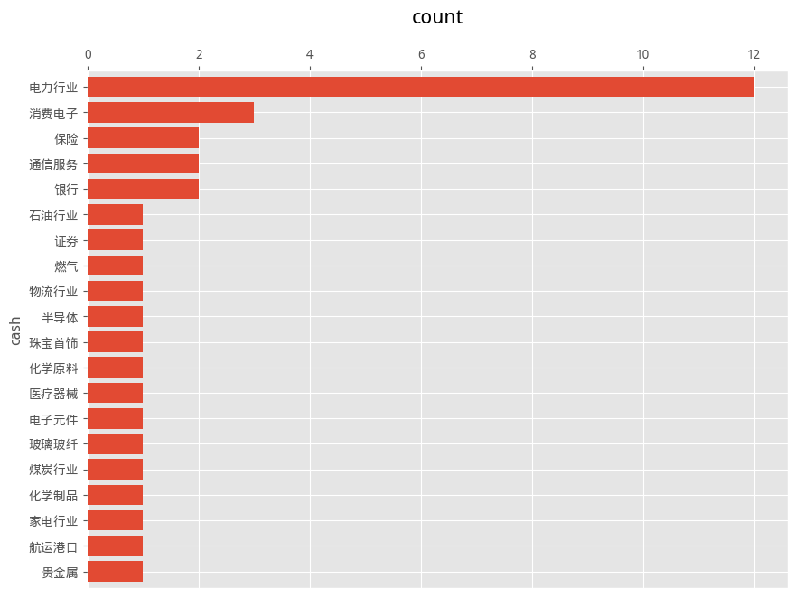

```
total: 38 | from 15 to 1
```

|  | 1 | 2 | 3 | 4 | 5 | 6 | 7 | 8 | 9 | 10 |
| --- | --- | --- | --- | --- | --- | --- | --- | --- | --- | --- |
| 0 | [国电电力](https://data.eastmoney.com/stockdata/600795.html) | [华电国际](https://data.eastmoney.com/stockdata/600027.html) | [紫金矿业](https://data.eastmoney.com/stockdata/601899.html) | [华能国际](https://data.eastmoney.com/stockdata/600011.html) | [深圳能源](https://data.eastmoney.com/stockdata/000027.html) | [长江电力](https://data.eastmoney.com/stockdata/600900.html) | [福耀玻璃](https://data.eastmoney.com/stockdata/600660.html) | [青岛啤酒](https://data.eastmoney.com/stockdata/600600.html) | [国投电力](https://data.eastmoney.com/stockdata/600886.html) | [北大荒](https://data.eastmoney.com/stockdata/600598.html) |
| 1 | [桂冠电力](https://data.eastmoney.com/stockdata/600236.html) | [中国人寿](https://data.eastmoney.com/stockdata/601628.html) | [中国联通](https://data.eastmoney.com/stockdata/600050.html) | [工商银行](https://data.eastmoney.com/stockdata/601398.html) | [中国太保](https://data.eastmoney.com/stockdata/601601.html) | [中国神华](https://data.eastmoney.com/stockdata/601088.html) | [万华化学](https://data.eastmoney.com/stockdata/600309.html) | [美的集团](https://data.eastmoney.com/stockdata/000333.html) | [蓝思科技](https://data.eastmoney.com/stockdata/300433.html) | [中国广核](https://data.eastmoney.com/stockdata/003816.html) |
| 2 | [中国核电](https://data.eastmoney.com/stockdata/601985.html) | [秦港股份](https://data.eastmoney.com/stockdata/601326.html) | [迈瑞医疗](https://data.eastmoney.com/stockdata/300760.html) | [鹏鼎控股](https://data.eastmoney.com/stockdata/002938.html) | [宝丰能源](https://data.eastmoney.com/stockdata/600989.html) | [财通证券](https://data.eastmoney.com/stockdata/601108.html) | [新天绿能](https://data.eastmoney.com/stockdata/600956.html) | [渝农商行](https://data.eastmoney.com/stockdata/601077.html) | [京沪高铁](https://data.eastmoney.com/stockdata/601816.html) | [中芯国际](https://data.eastmoney.com/stockdata/688981.html) |
| 3 | [三峡能源](https://data.eastmoney.com/stockdata/600905.html) | [龙源电力](https://data.eastmoney.com/stockdata/001289.html) | [菜百股份](https://data.eastmoney.com/stockdata/605599.html) | [中国移动](https://data.eastmoney.com/stockdata/600941.html) | [陕西能源](https://data.eastmoney.com/stockdata/001286.html) | [中国海油](https://data.eastmoney.com/stockdata/600938.html) | [华勤技术](https://data.eastmoney.com/stockdata/603296.html) | [龙旗科技](https://data.eastmoney.com/stockdata/603341.html) |  |  |

```
all time top 300 no cash: 60
total: 60 | from 15 to 4
```

|  | 1 | 2 | 3 | 4 | 5 | 6 | 7 | 8 | 9 | 10 |
| --- | --- | --- | --- | --- | --- | --- | --- | --- | --- | --- |
| 0 | [云南白药](https://data.eastmoney.com/stockdata/000538.html) | [中信银行](https://data.eastmoney.com/stockdata/601998.html) | [海螺水泥](https://data.eastmoney.com/stockdata/600585.html) | [平安银行](https://data.eastmoney.com/stockdata/000001.html) | [中国电建](https://data.eastmoney.com/stockdata/601669.html) | [浦发银行](https://data.eastmoney.com/stockdata/600000.html) | [宝钢股份](https://data.eastmoney.com/stockdata/600019.html) | [中国中冶](https://data.eastmoney.com/stockdata/601618.html) | [农业银行](https://data.eastmoney.com/stockdata/601288.html) | [海尔智家](https://data.eastmoney.com/stockdata/600690.html) |
| 1 | [洋河股份](https://data.eastmoney.com/stockdata/002304.html) | [招商银行](https://data.eastmoney.com/stockdata/600036.html) | [保利发展](https://data.eastmoney.com/stockdata/600048.html) | [中国化学](https://data.eastmoney.com/stockdata/601117.html) | [特变电工](https://data.eastmoney.com/stockdata/600089.html) | [中国神华](https://data.eastmoney.com/stockdata/601088.html) | [中国银行](https://data.eastmoney.com/stockdata/601988.html) | [兖矿能源](https://data.eastmoney.com/stockdata/600188.html) | [中国铁建](https://data.eastmoney.com/stockdata/601186.html) | [贵州茅台](https://data.eastmoney.com/stockdata/600519.html) |
| 2 | [中国电信](https://data.eastmoney.com/stockdata/601728.html) | [中国平安](https://data.eastmoney.com/stockdata/601318.html) | [中国建筑](https://data.eastmoney.com/stockdata/601668.html) | [中信证券](https://data.eastmoney.com/stockdata/600030.html) | [交通银行](https://data.eastmoney.com/stockdata/601328.html) | [中国交建](https://data.eastmoney.com/stockdata/601800.html) | [万华化学](https://data.eastmoney.com/stockdata/600309.html) | [民生银行](https://data.eastmoney.com/stockdata/600016.html) | [兴业银行](https://data.eastmoney.com/stockdata/601166.html) | [长江电力](https://data.eastmoney.com/stockdata/600900.html) |
| 3 | [中国太保](https://data.eastmoney.com/stockdata/601601.html) | [格力电器](https://data.eastmoney.com/stockdata/000651.html) | [中国中铁](https://data.eastmoney.com/stockdata/601390.html) | [光大银行](https://data.eastmoney.com/stockdata/601818.html) | [建设银行](https://data.eastmoney.com/stockdata/601939.html) | [伊利股份](https://data.eastmoney.com/stockdata/600887.html) | [大秦铁路](https://data.eastmoney.com/stockdata/601006.html) | [上汽集团](https://data.eastmoney.com/stockdata/600104.html) | [潍柴动力](https://data.eastmoney.com/stockdata/000338.html) | [中国人寿](https://data.eastmoney.com/stockdata/601628.html) |
| 4 | [建发股份](https://data.eastmoney.com/stockdata/600153.html) | [青岛啤酒](https://data.eastmoney.com/stockdata/600600.html) | [中国核电](https://data.eastmoney.com/stockdata/601985.html) | [美的集团](https://data.eastmoney.com/stockdata/000333.html) | [上海医药](https://data.eastmoney.com/stockdata/601607.html) | [华夏银行](https://data.eastmoney.com/stockdata/600015.html) | [工商银行](https://data.eastmoney.com/stockdata/601398.html) | [新华保险](https://data.eastmoney.com/stockdata/601336.html) | [浙能电力](https://data.eastmoney.com/stockdata/600023.html) | [国泰君安](https://data.eastmoney.com/stockdata/601211.html) |
| 5 | [中国广核](https://data.eastmoney.com/stockdata/003816.html) | [龙源电力](https://data.eastmoney.com/stockdata/001289.html) | [上海银行](https://data.eastmoney.com/stockdata/601229.html) | [江苏银行](https://data.eastmoney.com/stockdata/600919.html) | [浙商银行](https://data.eastmoney.com/stockdata/601916.html) | [工业富联](https://data.eastmoney.com/stockdata/601138.html) | [邮储银行](https://data.eastmoney.com/stockdata/601658.html) | [中国人保](https://data.eastmoney.com/stockdata/601319.html) | [中国移动](https://data.eastmoney.com/stockdata/600941.html) | [中国海油](https://data.eastmoney.com/stockdata/600938.html) |

```
all time top 300 in all cols: 13
total: 13 | from 15 to 4
```

|  | 1 | 2 | 3 | 4 | 5 | 6 | 7 | 8 | 9 | 10 |
| --- | --- | --- | --- | --- | --- | --- | --- | --- | --- | --- |
| 0 | [万华化学](https://data.eastmoney.com/stockdata/600309.html) | [美的集团](https://data.eastmoney.com/stockdata/000333.html) | [长江电力](https://data.eastmoney.com/stockdata/600900.html) | [中国核电](https://data.eastmoney.com/stockdata/601985.html) | [中国太保](https://data.eastmoney.com/stockdata/601601.html) | [中国神华](https://data.eastmoney.com/stockdata/601088.html) | [工商银行](https://data.eastmoney.com/stockdata/601398.html) | [青岛啤酒](https://data.eastmoney.com/stockdata/600600.html) | [中国人寿](https://data.eastmoney.com/stockdata/601628.html) | [中国广核](https://data.eastmoney.com/stockdata/003816.html) |
| 1 | [龙源电力](https://data.eastmoney.com/stockdata/001289.html) | [中国海油](https://data.eastmoney.com/stockdata/600938.html) | [中国移动](https://data.eastmoney.com/stockdata/600941.html) |  |  |  |  |  |  |  |

- 每年都能进入前300的，每个指标都不多。
- 最难保持进入的是现金的榜单。净资产巨头每年上榜的最多。

## 增长情况

- 选择了有6期以上报告的公司。用斜率除以残余标准差来衡量增长情况。

|  | revenue | profit | asset | cash |
| --- | --- | --- | --- | --- |
| 0 | [英特集团](https://data.eastmoney.com/stockdata/000411.html) | [招商银行](https://data.eastmoney.com/stockdata/600036.html) | [中国银行](https://data.eastmoney.com/stockdata/601988.html) | [中国国贸](https://data.eastmoney.com/stockdata/600007.html) |
| 1 | [千金药业](https://data.eastmoney.com/stockdata/600479.html) | [北京银行](https://data.eastmoney.com/stockdata/601169.html) | [明星电力](https://data.eastmoney.com/stockdata/600101.html) | [复星医药](https://data.eastmoney.com/stockdata/600196.html) |
| 2 | [省广集团](https://data.eastmoney.com/stockdata/002400.html) | [中电环保](https://data.eastmoney.com/stockdata/300172.html) | [兴业银行](https://data.eastmoney.com/stockdata/601166.html) | [片仔癀](https://data.eastmoney.com/stockdata/600436.html) |
| 3 | [广安爱众](https://data.eastmoney.com/stockdata/600979.html) | [南京银行](https://data.eastmoney.com/stockdata/601009.html) | [洋河股份](https://data.eastmoney.com/stockdata/002304.html) | [渤海租赁](https://data.eastmoney.com/stockdata/000415.html) |
| 4 | [兴森科技](https://data.eastmoney.com/stockdata/002436.html) | [美的集团](https://data.eastmoney.com/stockdata/000333.html) | [华润双鹤](https://data.eastmoney.com/stockdata/600062.html) | [恩华药业](https://data.eastmoney.com/stockdata/002262.html) |
| 5 | [招商银行](https://data.eastmoney.com/stockdata/600036.html) | [中信银行](https://data.eastmoney.com/stockdata/601998.html) | [建设银行](https://data.eastmoney.com/stockdata/601939.html) | [北大荒](https://data.eastmoney.com/stockdata/600598.html) |
| 6 | [云南白药](https://data.eastmoney.com/stockdata/000538.html) | [唐山港](https://data.eastmoney.com/stockdata/601000.html) | [农业银行](https://data.eastmoney.com/stockdata/601288.html) | [西藏药业](https://data.eastmoney.com/stockdata/600211.html) |
| 7 | [国药一致](https://data.eastmoney.com/stockdata/000028.html) | [京新药业](https://data.eastmoney.com/stockdata/002020.html) | [大秦铁路](https://data.eastmoney.com/stockdata/601006.html) | [旺能环境](https://data.eastmoney.com/stockdata/002034.html) |
| 8 | [卧龙电驱](https://data.eastmoney.com/stockdata/600580.html) | [中国建筑](https://data.eastmoney.com/stockdata/601668.html) | [铁龙物流](https://data.eastmoney.com/stockdata/600125.html) | [广汇能源](https://data.eastmoney.com/stockdata/600256.html) |
| 9 | [南京银行](https://data.eastmoney.com/stockdata/601009.html) | [兴业银行](https://data.eastmoney.com/stockdata/601166.html) | [深圳燃气](https://data.eastmoney.com/stockdata/601139.html) | [济川药业](https://data.eastmoney.com/stockdata/600566.html) |
| 10 | [圣农发展](https://data.eastmoney.com/stockdata/002299.html) | [联环药业](https://data.eastmoney.com/stockdata/600513.html) | [康缘药业](https://data.eastmoney.com/stockdata/600557.html) | [ST新潮](https://data.eastmoney.com/stockdata/600777.html) |
| 11 | [上海医药](https://data.eastmoney.com/stockdata/601607.html) | [丽珠集团](https://data.eastmoney.com/stockdata/000513.html) | [东方电气](https://data.eastmoney.com/stockdata/600875.html) | [分众传媒](https://data.eastmoney.com/stockdata/002027.html) |
| 12 | [惠天热电](https://data.eastmoney.com/stockdata/000692.html) | [济川药业](https://data.eastmoney.com/stockdata/600566.html) | [川投能源](https://data.eastmoney.com/stockdata/600674.html) | [中兴通讯](https://data.eastmoney.com/stockdata/000063.html) |
| 13 | [海格通信](https://data.eastmoney.com/stockdata/002465.html) | [汉森制药](https://data.eastmoney.com/stockdata/002412.html) | [皖通高速](https://data.eastmoney.com/stockdata/600012.html) | [中鼎股份](https://data.eastmoney.com/stockdata/000887.html) |
| 14 | [嘉事堂](https://data.eastmoney.com/stockdata/002462.html) | [中国国贸](https://data.eastmoney.com/stockdata/600007.html) | [航天信息](https://data.eastmoney.com/stockdata/600271.html) | [天源迪科](https://data.eastmoney.com/stockdata/300047.html) |
| 15 | [九州通](https://data.eastmoney.com/stockdata/600998.html) | [老板电器](https://data.eastmoney.com/stockdata/002508.html) | [金地集团](https://data.eastmoney.com/stockdata/600383.html) | [安科生物](https://data.eastmoney.com/stockdata/300009.html) |
| 16 | [中炬高新](https://data.eastmoney.com/stockdata/600872.html) | [中国电建](https://data.eastmoney.com/stockdata/601669.html) | [兴蓉环境](https://data.eastmoney.com/stockdata/000598.html) | [华金资本](https://data.eastmoney.com/stockdata/000532.html) |
| 17 | [丽珠集团](https://data.eastmoney.com/stockdata/000513.html) | [恩华药业](https://data.eastmoney.com/stockdata/002262.html) | [辽宁成大](https://data.eastmoney.com/stockdata/600739.html) | [福耀玻璃](https://data.eastmoney.com/stockdata/600660.html) |
| 18 | [东方国信](https://data.eastmoney.com/stockdata/300166.html) | [光大银行](https://data.eastmoney.com/stockdata/601818.html) | [远光软件](https://data.eastmoney.com/stockdata/002063.html) | [海峡股份](https://data.eastmoney.com/stockdata/002320.html) |
| 19 | [数字政通](https://data.eastmoney.com/stockdata/300075.html) | [宁波银行](https://data.eastmoney.com/stockdata/002142.html) | [北部湾港](https://data.eastmoney.com/stockdata/000582.html) | [南山铝业](https://data.eastmoney.com/stockdata/600219.html) |

```
slope top 300 no cash: 65
total: 30 | top 20 : 84.62%
```

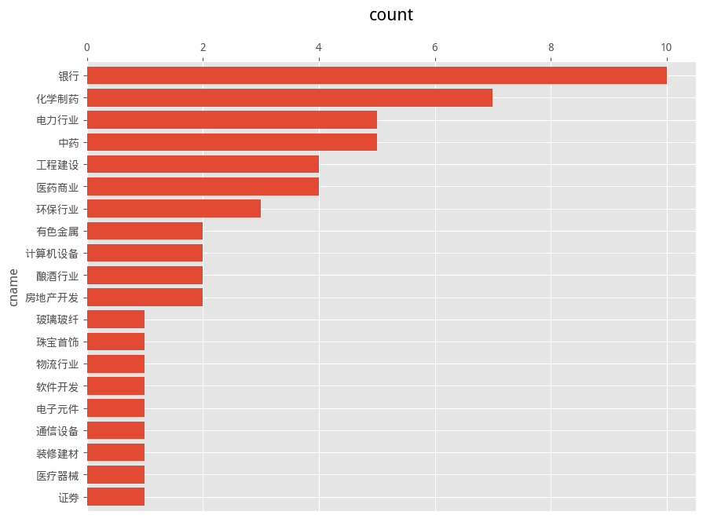

```
total: 65 | from 1.34 to 0.57
```

|  | 1 | 2 | 3 | 4 | 5 | 6 | 7 | 8 | 9 | 10 |
| --- | --- | --- | --- | --- | --- | --- | --- | --- | --- | --- |
| 0 | [招商银行](https://data.eastmoney.com/stockdata/600036.html) | [国药一致](https://data.eastmoney.com/stockdata/000028.html) | [卧龙电驱](https://data.eastmoney.com/stockdata/600580.html) | [南京银行](https://data.eastmoney.com/stockdata/601009.html) | [上海医药](https://data.eastmoney.com/stockdata/601607.html) | [海格通信](https://data.eastmoney.com/stockdata/002465.html) | [数字政通](https://data.eastmoney.com/stockdata/300075.html) | [羚锐制药](https://data.eastmoney.com/stockdata/600285.html) | [海康威视](https://data.eastmoney.com/stockdata/002415.html) | [老板电器](https://data.eastmoney.com/stockdata/002508.html) |
| 1 | [华东医药](https://data.eastmoney.com/stockdata/000963.html) | [京新药业](https://data.eastmoney.com/stockdata/002020.html) | [平安银行](https://data.eastmoney.com/stockdata/000001.html) | [中国国贸](https://data.eastmoney.com/stockdata/600007.html) | [兴业银行](https://data.eastmoney.com/stockdata/601166.html) | [华海药业](https://data.eastmoney.com/stockdata/600521.html) | [广电运通](https://data.eastmoney.com/stockdata/002152.html) | [南京医药](https://data.eastmoney.com/stockdata/600713.html) | [物产中大](https://data.eastmoney.com/stockdata/600704.html) | [华夏银行](https://data.eastmoney.com/stockdata/600015.html) |
| 2 | [中国银行](https://data.eastmoney.com/stockdata/601988.html) | [中国建筑](https://data.eastmoney.com/stockdata/601668.html) | [安科生物](https://data.eastmoney.com/stockdata/300009.html) | [龙净环保](https://data.eastmoney.com/stockdata/600388.html) | [兴蓉环境](https://data.eastmoney.com/stockdata/000598.html) | [伟星新材](https://data.eastmoney.com/stockdata/002372.html) | [老凤祥](https://data.eastmoney.com/stockdata/600612.html) | [福能股份](https://data.eastmoney.com/stockdata/600483.html) | [贵州茅台](https://data.eastmoney.com/stockdata/600519.html) | [洋河股份](https://data.eastmoney.com/stockdata/002304.html) |
| 3 | [沃尔核材](https://data.eastmoney.com/stockdata/002130.html) | [光大银行](https://data.eastmoney.com/stockdata/601818.html) | [瀚蓝环境](https://data.eastmoney.com/stockdata/600323.html) | [康缘药业](https://data.eastmoney.com/stockdata/600557.html) | [保利发展](https://data.eastmoney.com/stockdata/600048.html) | [农业银行](https://data.eastmoney.com/stockdata/601288.html) | [丰原药业](https://data.eastmoney.com/stockdata/000153.html) | [福耀玻璃](https://data.eastmoney.com/stockdata/600660.html) | [恒瑞医药](https://data.eastmoney.com/stockdata/600276.html) | [普洛药业](https://data.eastmoney.com/stockdata/000739.html) |
| 4 | [昆药集团](https://data.eastmoney.com/stockdata/600422.html) | [鱼跃医疗](https://data.eastmoney.com/stockdata/002223.html) | [东南网架](https://data.eastmoney.com/stockdata/002135.html) | [江苏神通](https://data.eastmoney.com/stockdata/002438.html) | [回天新材](https://data.eastmoney.com/stockdata/300041.html) | [交通银行](https://data.eastmoney.com/stockdata/601328.html) | [国药股份](https://data.eastmoney.com/stockdata/600511.html) | [航天电子](https://data.eastmoney.com/stockdata/600879.html) | [顺络电子](https://data.eastmoney.com/stockdata/002138.html) | [联环药业](https://data.eastmoney.com/stockdata/600513.html) |
| 5 | [银轮股份](https://data.eastmoney.com/stockdata/002126.html) | [白云山](https://data.eastmoney.com/stockdata/600332.html) | [长江电力](https://data.eastmoney.com/stockdata/600900.html) | [永新股份](https://data.eastmoney.com/stockdata/002014.html) | [仁和药业](https://data.eastmoney.com/stockdata/000650.html) | [中信证券](https://data.eastmoney.com/stockdata/600030.html) | [中国中铁](https://data.eastmoney.com/stockdata/601390.html) | [国投电力](https://data.eastmoney.com/stockdata/600886.html) | [中国铁建](https://data.eastmoney.com/stockdata/601186.html) | [明星电力](https://data.eastmoney.com/stockdata/600101.html) |
| 6 | [建设银行](https://data.eastmoney.com/stockdata/601939.html) | [中电环保](https://data.eastmoney.com/stockdata/300172.html) | [吉电股份](https://data.eastmoney.com/stockdata/000875.html) | [海亮股份](https://data.eastmoney.com/stockdata/002203.html) | [亚太科技](https://data.eastmoney.com/stockdata/002540.html) |  |  |  |  |  |

```
slope top 300 in all cols: 19
total: 14 | top 20 : 100.00%
```

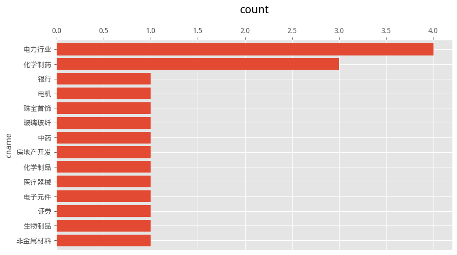

```
total: 19 | from 1.3 to 0.58
```

|  | 1 | 2 | 3 | 4 | 5 | 6 | 7 | 8 | 9 | 10 |
| --- | --- | --- | --- | --- | --- | --- | --- | --- | --- | --- |
| 0 | [卧龙电驱](https://data.eastmoney.com/stockdata/600580.html) | [羚锐制药](https://data.eastmoney.com/stockdata/600285.html) | [京新药业](https://data.eastmoney.com/stockdata/002020.html) | [中国国贸](https://data.eastmoney.com/stockdata/600007.html) | [华海药业](https://data.eastmoney.com/stockdata/600521.html) | [安科生物](https://data.eastmoney.com/stockdata/300009.html) | [老凤祥](https://data.eastmoney.com/stockdata/600612.html) | [沃尔核材](https://data.eastmoney.com/stockdata/002130.html) | [福耀玻璃](https://data.eastmoney.com/stockdata/600660.html) | [普洛药业](https://data.eastmoney.com/stockdata/000739.html) |
| 1 | [鱼跃医疗](https://data.eastmoney.com/stockdata/002223.html) | [回天新材](https://data.eastmoney.com/stockdata/300041.html) | [顺络电子](https://data.eastmoney.com/stockdata/002138.html) | [长江电力](https://data.eastmoney.com/stockdata/600900.html) | [中信证券](https://data.eastmoney.com/stockdata/600030.html) | [国投电力](https://data.eastmoney.com/stockdata/600886.html) | [明星电力](https://data.eastmoney.com/stockdata/600101.html) | [建设银行](https://data.eastmoney.com/stockdata/601939.html) | [吉电股份](https://data.eastmoney.com/stockdata/000875.html) |  |

- 巨头还是比较多。但这个指标找出来一些至少在图上比较好看的公司。

## 金额和增长

- 不计算cash, 金额每年都进入前300, 增长也进入前300。

```
total: 18 | from 15 to 15
total: 7 | top 20 : 100.00%
```

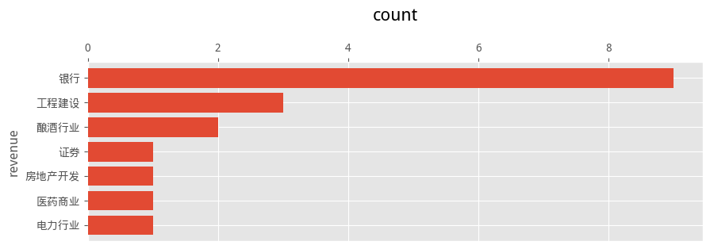

- 各种指标的体量大，同时增长率也较好的公司很少，这个列表没什么惊喜。